# Car Prices

## Define a polytomic factor f.age for the covariate car age according to its quartiles and argue if the average price depends on the level of age. Statistically justify the answer.

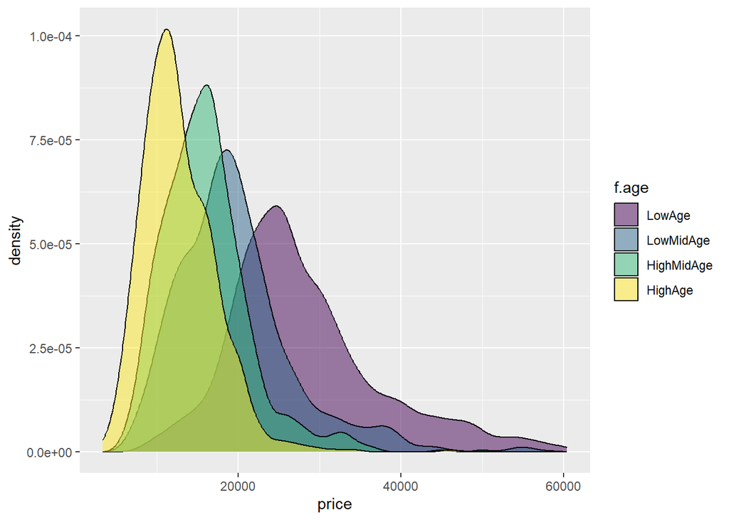

```r
ggplot(df, aes(x=price, fill=f.age)) +
  geom_density(alpha=.5)
```

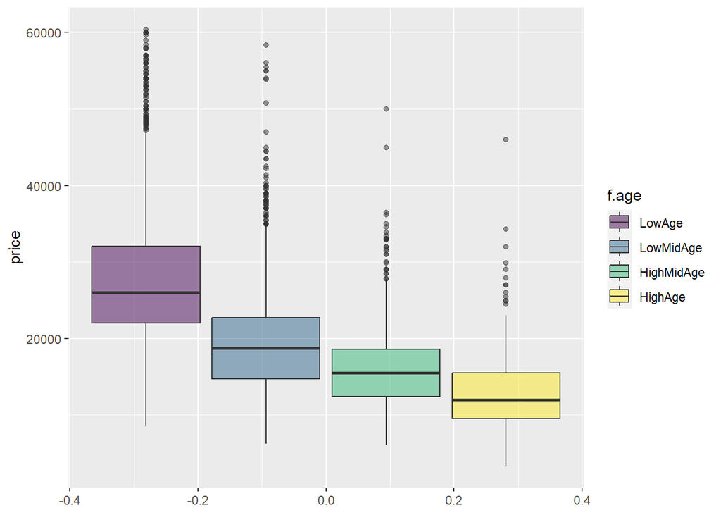

```r
ggplot(df, aes(y=price, fill=f.age)) +
  geom_boxplot(alpha=0.5)
```

We perform pairwise wilcoxon test to check for similar means. Looking at the boxplot and distribution plot we can already expect that these are not going to be similar. The result of the wilcoxon test indicates our hypothesis was right that there is a clear difference between the means of the different quartiles.

```r
pairwise.wilcox.test(df$price, df$f.age)
```

```
##
##  Pairwise comparisons using Wilcoxon rank sum test with continuity correction
##
## data:  df$price and df$f.age
##
##            LowAge LowMidAge HighMidAge
## LowMidAge  <2e-16 -         -
## HighMidAge <2e-16 <2e-16    -
## HighAge    <2e-16 <2e-16    <2e-16
##
## P value adjustment method: holm
```

We perform kolmogorov-Smirnov test whether the distributions of 2 quartiles are the same. From the plot above we can already assume that is likely these test are all going to reject the Null hypothesis, but we will check anyway.

AgeQ1 vs AgeQ2: distributions are not similar.

```r
ks.test(df$price[df$f.age=="LowAge"], df$price[df$f.age=="LowMidAge"])
```

```
##
##  Asymptotic two-sample Kolmogorov-Smirnov test
##
## data:  df$price[df$f.age == "LowAge"] and df$price[df$f.age == "LowMidAge"]
## D = 0.47792, p-value < 2.2e-16
## alternative hypothesis: two-sided
```

AgeQ1 vs AgeQ3: distributions are not similar.

```r
ks.test(df$price[df$f.age=="LowAge"], df$price[df$f.age=="HighMidAge"])
```

```
##
##  Asymptotic two-sample Kolmogorov-Smirnov test
##
## data:  df$price[df$f.age == "LowAge"] and df$price[df$f.age == "HighMidAge"]
## D = 0.68707, p-value < 2.2e-16
## alternative hypothesis: two-sided
```

AgeQ1 vs AgeQ4: distributions are not similar.

```r
ks.test(df$price[df$f.age=="LowAge"], df$price[df$f.age=="HighAge"])
```

```
##
##  Asymptotic two-sample Kolmogorov-Smirnov test
##
## data:  df$price[df$f.age == "LowAge"] and df$price[df$f.age == "HighAge"]
## D = 0.81035, p-value < 2.2e-16
## alternative hypothesis: two-sided
```

AgeQ3 vs AgeQ2: distributions are not similar.

```r
ks.test(df$price[df$f.age=="HighMidAge"], df$price[df$f.age=="LowMidAge"])
```

```
##
##  Asymptotic two-sample Kolmogorov-Smirnov test
##
## data:  df$price[df$f.age == "HighMidAge"] and df$price[df$f.age == "LowMidAge"]
## D = 0.27428, p-value < 2.2e-16
## alternative hypothesis: two-sided
```

AgeQ4 vs AgeQ2: distributions are not similar.

```r
ks.test(df$price[df$f.age=="HighAge"], df$price[df$f.age=="LowMidAge"])
```

```
##
##  Asymptotic two-sample Kolmogorov-Smirnov test
##
## data:  df$price[df$f.age == "HighAge"] and df$price[df$f.age == "LowMidAge"]
## D = 0.49092, p-value < 2.2e-16
## alternative hypothesis: two-sided
```

AgeQ4 vs AgeQ3: distributions are not similar.

```r
ks.test(df$price[df$f.age=="HighAge"], df$price[df$f.age=="HighMidAge"])
```

```
##
##  Asymptotic two-sample Kolmogorov-Smirnov test
##
## data:  df$price[df$f.age == "HighAge"] and df$price[df$f.age == "HighMidAge"]
## D = 0.31515, p-value < 2.2e-16
## alternative hypothesis: two-sided
```

# Price Modelling

## Calculate the linear regression model that explains the price from the age: interpret the regression line and assess its quality.

A linear model using the logarithmic price and n.age variable is constructed. It yields an R-sq of 46%, which is insufficient for accurate predictions. However, all diagnostic plots show solid results. The residuals vs fitted plot yields a more or less straight line which confirms linearity. The Q-Q plot indicates more or less normally distributed standard errors in the model. The scale-location plot gives a straight line which indicates that homoscedastisity is satisfied. The Residuals vs. leverage plot shows that there are some high leverage points in the model. However, they more or less lie in a straight line which indicates that there are no severe contradicting high-leverage instances in our simple model. An influence plot confirms this behaviour.

```r
require(MASS)
lmAgeLog = lm(log(price)~n.age, data = df)
par(mfrow=c(2,2))
summary(lmAgeLog)
```

```
##
## Call:
## lm(formula = log(price) ~ n.age, data = df)
##
## Residuals:
##      Min       1Q   Median       3Q      Max
## -1.14028 -0.19935  0.00052  0.19819  1.24347
##
## Coefficients:
##              Estimate Std. Error t value Pr(>|t|)
## (Intercept) 10.298277   0.008146 1264.19   <2e-16 ***
## n.age       -0.161069   0.002502  -64.36   <2e-16 ***
## ---
## Signif. codes:  0 '***' 0.001 '**' 0.01 '*' 0.05 '.' 0.1 ' ' 1
##
## Residual standard error: 0.3269 on 4801 degrees of freedom
## Multiple R-squared:  0.4632, Adjusted R-squared:  0.4631
## F-statistic:  4143 on 1 and 4801 DF,  p-value: < 2.2e-16
```

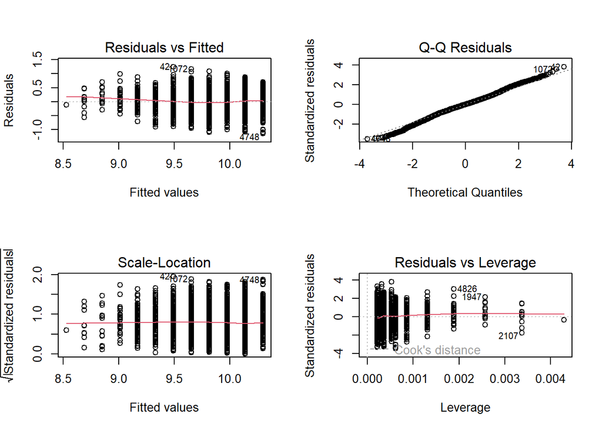

```r
plot(lmAgeLog)
```

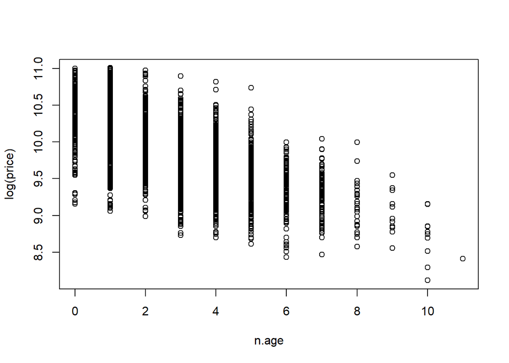

```r
par(mfrow=c(1,1))
plot(log(price) ~ n.age, data = df)
```

```r
influencePlot(lmAgeLog)
```

```
##         StudRes          Hat        CookD
## 42    3.8101204 0.0005307294 0.0038435282
## 752   1.4431868 0.0033704976 0.0035210927
## 1072  3.5704214 0.0003143748 0.0019995480
## 1844 -0.3515391 0.0042900503 0.0002662724
## 1947  2.1392082 0.0025681446 0.0058869312
## 4826  3.0303112 0.0018829912 0.0086471251
```

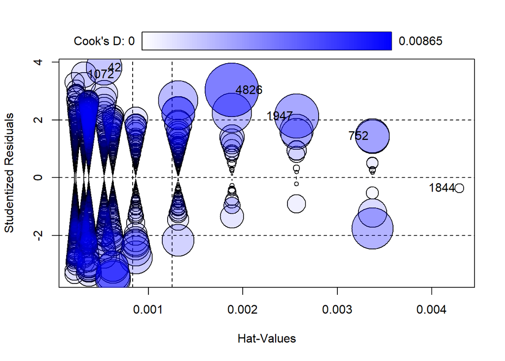

```r
abline(lmAgeLog, col="red")
```

## What is the percentage of the price variability that is explained by the age of the car?

As explained in question 6: for the log(price) ~ n.age model about 46% of the price variability is explained. This is insufficient for accurate prediction, such that additional explanatory variables are expected to be useful.

##. Do you think it is necessary to introduce a quadratic term in the equation that relates the price to its age?

To see if a polynomial transformation on n.age might be beneficial, the boxTidwell function is applied on the linear model (in which a constant term that doesnt influence results is added as the function can’t handle zero values on the age). This function returns a lambda value of 0.87. This value seems to indicate that introducing a polynomial term to the age is unnecessary. However, to further confirm this believe, a transformation in the order of the square root is applied and evaluated.

Concluding, as the benefit of adding a polynomial term to the model, in terms of explainability, is very small, and as the quadratic models might be more biased towards values with high leverage, it is not necessary to add a quadratic term.

```r
boxTidwell(log(price)~I(n.age+0.001), data = df)
```

```
##  MLE of lambda Score Statistic (t) Pr(>|t|)
##        0.87201              4.7739 1.86e-06 ***
## ---
## Signif. codes:  0 '***' 0.001 '**' 0.01 '*' 0.05 '.' 0.1 ' ' 1
##
## iterations =  4
```

```r
lmAgeLogSqrt = lm(log(price)~(sqrt(n.age)+n.age), data=df)

summary(lmAgeLog)
```

```
##
## Call:
## lm(formula = log(price) ~ n.age, data = df)
##
## Residuals:
##      Min       1Q   Median       3Q      Max
## -1.14028 -0.19935  0.00052  0.19819  1.24347
##
## Coefficients:
##              Estimate Std. Error t value Pr(>|t|)
## (Intercept) 10.298277   0.008146 1264.19   <2e-16 ***
## n.age       -0.161069   0.002502  -64.36   <2e-16 ***
## ---
## Signif. codes:  0 '***' 0.001 '**' 0.01 '*' 0.05 '.' 0.1 ' ' 1
##
## Residual standard error: 0.3269 on 4801 degrees of freedom
## Multiple R-squared:  0.4632, Adjusted R-squared:  0.4631
## F-statistic:  4143 on 1 and 4801 DF,  p-value: < 2.2e-16
```

```r
summary(lmAgeLogSqrt)
```

```
##
## Call:
## lm(formula = log(price) ~ (sqrt(n.age) + n.age), data = df)
##
## Residuals:
##      Min       1Q   Median       3Q      Max
## -1.17479 -0.19829 -0.00186  0.20164  1.24201
##
## Coefficients:
##              Estimate Std. Error t value Pr(>|t|)
## (Intercept) 10.332780   0.017220 600.051   <2e-16 ***
## sqrt(n.age) -0.054983   0.024179  -2.274    0.023 *
## n.age       -0.143090   0.008293 -17.255   <2e-16 ***
## ---
## Signif. codes:  0 '***' 0.001 '**' 0.01 '*' 0.05 '.' 0.1 ' ' 1
##
## Residual standard error: 0.3268 on 4800 degrees of freedom
## Multiple R-squared:  0.4638, Adjusted R-squared:  0.4636
## F-statistic:  2076 on 2 and 4800 DF,  p-value: < 2.2e-16
```

```r
anova(lmAgeLog, lmAgeLogSqrt)
```

```
## Analysis of Variance Table
##
## Model 1: log(price) ~ n.age
## Model 2: log(price) ~ (sqrt(n.age) + n.age)
##   Res.Df    RSS Df Sum of Sq      F  Pr(>F)
## 1   4801 513.07
## 2   4800 512.51  1   0.55212 5.1709 0.02301 *
## ---
## Signif. codes:  0 '***' 0.001 '**' 0.01 '*' 0.05 '.' 0.1 ' ' 1
```

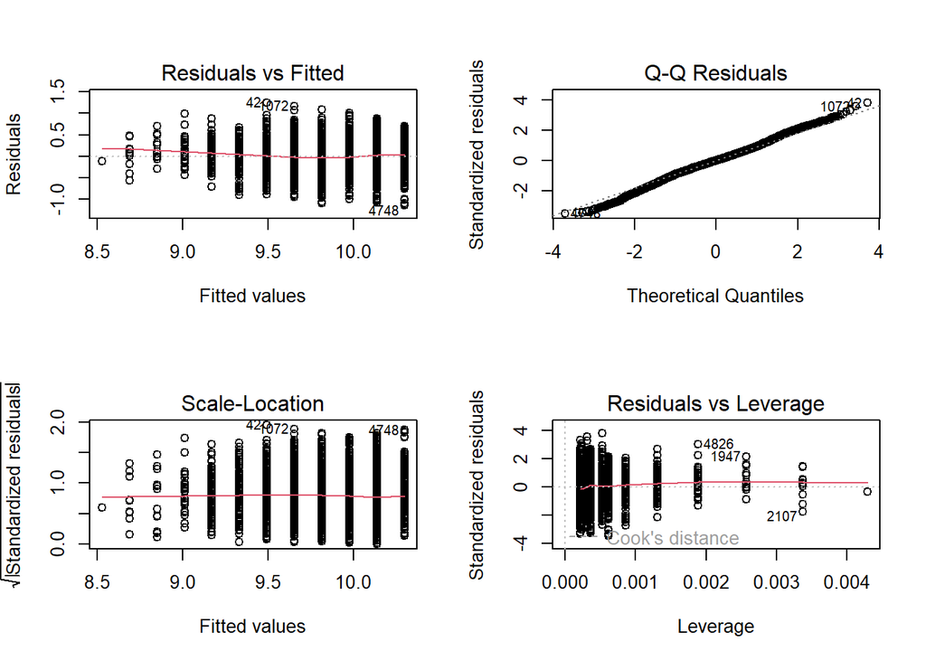

```r
par(mfrow=c(2,2))

plot(lmAgeLog)
```

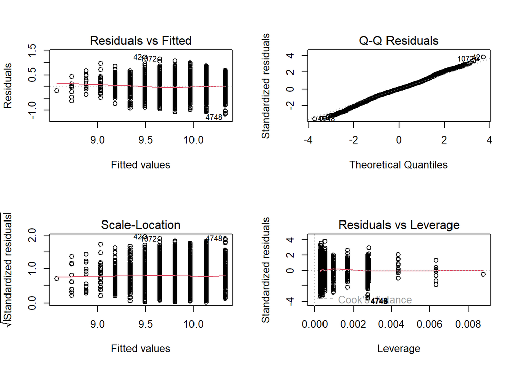

```r
plot(lmAgeLogSqrt)
```

```r
AIC(lmAgeLog, lmAgeLogSqrt)
```

```
##              df      AIC
## lmAgeLog      3 2893.977
## lmAgeLogSqrt  4 2890.805
```

```r
rm(lmAgeLogSqrt)
```

## Are there any additional explanatory numeric variables needed to the car price? Study collinearity effects.

First, all remaining numeric variables are naively additively added to the model. This yields a signficantly better prediction model with an R-sq of about 83%. However, to simplify our model, collinearity is investigated to see if there are variables that are redundant in our model.

First a correlation matrix is plotted. This hints that possible candidates for linearity are: mileage & age (rho = 0.80) and tax & mpg (rho = -0.61). Next, the variance inflation factor is calculated for the numeric variables. This indicates whether or not a variable correlates too much with other predictors such that it becomes redundant in the model. In general, a VIF-value larger than 1/(1-R_sq) is considered as showing too much collinear behaviour. The result for every variable is always significantly below this threshold such that no severe collinearity is detected in the model. To further confirm this hypothesis, models are build by alternately removing the highly correlated variables from the logarithmic model. Then, ANOVA is applied to test whether or not the models are significantly predicting something else and AIC to see what model is considered the best. These tests show that the model with all numeric variables performs the best and that no severe collinearity is present in our model.

Therefore, the model of choice for the continuation of the project will be the one with all numeric variables.

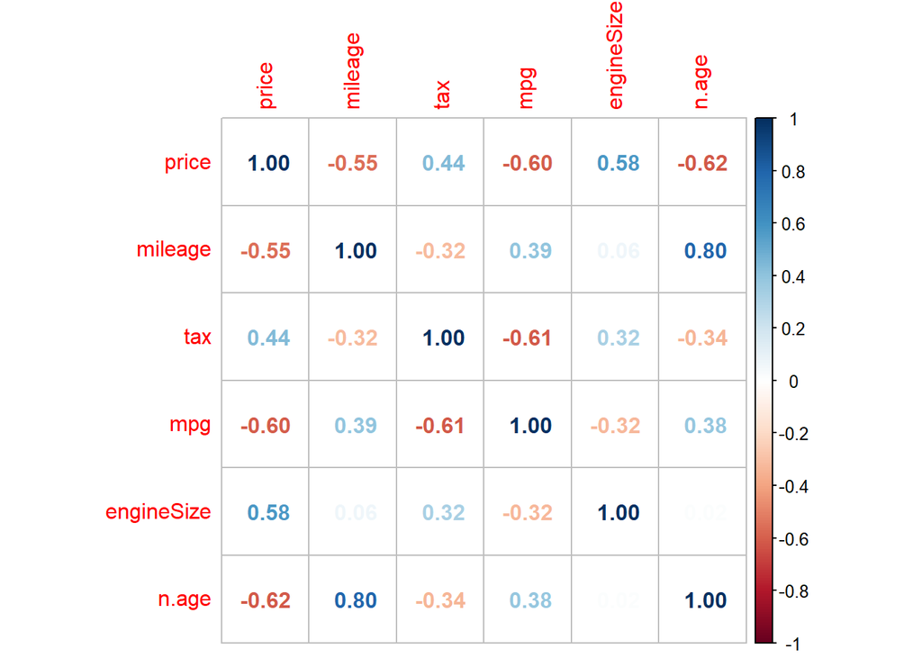

```r
lmNumLog = lm(log(price) ~ n.age+mileage+tax+mpg+engineSize, data=df)
t = summary(lmNumLog)

df_num = df[,c(3,5,7,8,9,11)]
cor_num = cor(df_num)
par(mfrow=c(1,1))
corrplot(cor_num, method = 'number')
```

```r
vif(lmNumLog)
```

```
##      n.age    mileage        tax        mpg engineSize
##   2.787241   2.853722   1.698470   1.823098   1.219252
```

```r
lmNumLog2 = lm(log(price) ~ n.age+tax+mpg+engineSize, data=df)
lmNumLog3 = lm(log(price) ~ n.age+mileage+mpg+engineSize, data=df)
lmNumLog4 = lm(log(price) ~ n.age+tax+mileage+engineSize, data=df)

anova(lmNumLog, lmNumLog2)
```

```
## Analysis of Variance Table
##
## Model 1: log(price) ~ n.age + mileage + tax + mpg + engineSize
## Model 2: log(price) ~ n.age + tax + mpg + engineSize
##   Res.Df    RSS Df Sum of Sq      F    Pr(>F)
## 1   4797 164.46
## 2   4798 180.22 -1   -15.753 459.47 < 2.2e-16 ***
## ---
## Signif. codes:  0 '***' 0.001 '**' 0.01 '*' 0.05 '.' 0.1 ' ' 1
```

```r
anova(lmNumLog, lmNumLog3)
```

```
## Analysis of Variance Table
##
## Model 1: log(price) ~ n.age + mileage + tax + mpg + engineSize
## Model 2: log(price) ~ n.age + mileage + mpg + engineSize
##   Res.Df    RSS Df Sum of Sq      F    Pr(>F)
## 1   4797 164.46
## 2   4798 164.88 -1  -0.41208 12.019 0.0005311 ***
## ---
## Signif. codes:  0 '***' 0.001 '**' 0.01 '*' 0.05 '.' 0.1 ' ' 1
```

```r
anova(lmNumLog, lmNumLog4)
```

```
## Analysis of Variance Table
##
## Model 1: log(price) ~ n.age + mileage + tax + mpg + engineSize
## Model 2: log(price) ~ n.age + tax + mileage + engineSize
##   Res.Df    RSS Df Sum of Sq      F    Pr(>F)
## 1   4797 164.46
## 2   4798 176.27 -1   -11.805 344.32 < 2.2e-16 ***
## ---
## Signif. codes:  0 '***' 0.001 '**' 0.01 '*' 0.05 '.' 0.1 ' ' 1
```

```r
AIC(lmNumLog, lmNumLog2, lmNumLog3, lmNumLog4)
```

```
##           df       AIC
## lmNumLog   7 -2562.489
## lmNumLog2  6 -2125.166
## lmNumLog3  6 -2552.470
## lmNumLog4  6 -2231.546
```

## After controlling by numerical variables, indicate whether the additive effect of the available factors on the price are statistically significant.

All the remaining available factors (except the ones defined on the numeric variables like fe. f.age) are now added one by one to the current model. This yields an improvement of R-sq of about 6%. An anova test indicates significant difference in prediction. The vif function indicates no significant collinearity by introducing the factors. Finally, the AIC function shows that the model with the factors is significantly better than the one without. Therefore, it can be concluded that the effect of the available factors is statistically significant and positive in its prediction capabilities.

```r
lmNumLog = lm(log(price) ~ n.age+tax+mileage+engineSize+mpg, data=df)
lmFactLog = lm(log(price) ~ n.age+tax+mileage+engineSize+mpg+transmission+fuelType+manufacturer, data=df)

summary(lmNumLog)
```

```
##
## Call:
## lm(formula = log(price) ~ n.age + tax + mileage + engineSize +
##     mpg, data = df)
##
## Residuals:
##      Min       1Q   Median       3Q      Max
## -0.69196 -0.11721  0.00784  0.12571  0.85906
##
## Coefficients:
##               Estimate Std. Error t value Pr(>|t|)
## (Intercept)  9.736e+00  2.455e-02 396.579  < 2e-16 ***
## n.age       -1.069e-01  2.366e-03 -45.175  < 2e-16 ***
## tax          2.079e-04  5.997e-05   3.467 0.000531 ***
## mileage     -4.896e-06  2.284e-07 -21.435  < 2e-16 ***
## engineSize   4.287e-01  5.485e-03  78.148  < 2e-16 ***
## mpg         -5.947e-03  3.205e-04 -18.556  < 2e-16 ***
## ---
## Signif. codes:  0 '***' 0.001 '**' 0.01 '*' 0.05 '.' 0.1 ' ' 1
##
## Residual standard error: 0.1852 on 4797 degrees of freedom
## Multiple R-squared:  0.8279, Adjusted R-squared:  0.8277
## F-statistic:  4616 on 5 and 4797 DF,  p-value: < 2.2e-16
```

```r
summary(lmFactLog)
```

```
##
## Call:
## lm(formula = log(price) ~ n.age + tax + mileage + engineSize +
##     mpg + transmission + fuelType + manufacturer, data = df)
##
## Residuals:
##      Min       1Q   Median       3Q      Max
## -0.58978 -0.09360  0.00540  0.09988  0.76947
##
## Coefficients:
##                         Estimate Std. Error t value Pr(>|t|)
## (Intercept)            1.043e+01  3.103e-02 336.137  < 2e-16 ***
## n.age                 -9.847e-02  1.985e-03 -49.599  < 2e-16 ***
## tax                   -9.162e-05  5.032e-05  -1.821  0.06872 .
## mileage               -4.683e-06  1.896e-07 -24.697  < 2e-16 ***
## engineSize             2.803e-01  6.564e-03  42.699  < 2e-16 ***
## mpg                   -1.083e-02  3.506e-04 -30.888  < 2e-16 ***
## transmissionManual    -9.291e-02  6.711e-03 -13.844  < 2e-16 ***
## transmissionSemi-Auto  1.032e-02  5.683e-03   1.815  0.06959 .
## fuelTypeOther          1.507e-01  2.825e-02   5.335 9.99e-08 ***
## fuelTypePetrol        -1.107e-01  6.647e-03 -16.651  < 2e-16 ***
## manufacturerBMW       -8.466e-02  7.039e-03 -12.027  < 2e-16 ***
## manufacturerMercedes   1.844e-02  6.831e-03   2.699  0.00697 **
## manufacturerVW        -1.780e-01  6.330e-03 -28.112  < 2e-16 ***
## ---
## Signif. codes:  0 '***' 0.001 '**' 0.01 '*' 0.05 '.' 0.1 ' ' 1
##
## Residual standard error: 0.1526 on 4790 degrees of freedom
## Multiple R-squared:  0.8833, Adjusted R-squared:  0.883
## F-statistic:  3021 on 12 and 4790 DF,  p-value: < 2.2e-16
```

```r
anova(lmFactLog, lmNumLog)
```

```
## Analysis of Variance Table
##
## Model 1: log(price) ~ n.age + tax + mileage + engineSize + mpg + transmission +
##     fuelType + manufacturer
## Model 2: log(price) ~ n.age + tax + mileage + engineSize + mpg
##   Res.Df    RSS Df Sum of Sq      F    Pr(>F)
## 1   4790 111.53
## 2   4797 164.46 -7   -52.929 324.74 < 2.2e-16 ***
## ---
## Signif. codes:  0 '***' 0.001 '**' 0.01 '*' 0.05 '.' 0.1 ' ' 1
```

```r
vif(lmFactLog)
```

```
##                  GVIF Df GVIF^(1/(2*Df))
## n.age        2.888595  1        1.699587
## tax          1.761238  1        1.327117
## mileage      2.896132  1        1.701803
## engineSize   2.570926  1        1.603411
## mpg          3.211970  1        1.792197
## transmission 1.607446  2        1.125989
## fuelType     2.259803  2        1.226077
## manufacturer 1.513351  3        1.071495
```

```r
AIC(lmFactLog, lmNumLog)
```

```
##           df       AIC
## lmFactLog 14 -4413.783
## lmNumLog   7 -2562.489
```

```r
summary(lmFactLog)
```

```
##
## Call:
## lm(formula = log(price) ~ n.age + tax + mileage + engineSize +
##     mpg + transmission + fuelType + manufacturer, data = df)
##
## Residuals:
##      Min       1Q   Median       3Q      Max
## -0.58978 -0.09360  0.00540  0.09988  0.76947
##
## Coefficients:
##                         Estimate Std. Error t value Pr(>|t|)
## (Intercept)            1.043e+01  3.103e-02 336.137  < 2e-16 ***
## n.age                 -9.847e-02  1.985e-03 -49.599  < 2e-16 ***
## tax                   -9.162e-05  5.032e-05  -1.821  0.06872 .
## mileage               -4.683e-06  1.896e-07 -24.697  < 2e-16 ***
## engineSize             2.803e-01  6.564e-03  42.699  < 2e-16 ***
## mpg                   -1.083e-02  3.506e-04 -30.888  < 2e-16 ***
## transmissionManual    -9.291e-02  6.711e-03 -13.844  < 2e-16 ***
## transmissionSemi-Auto  1.032e-02  5.683e-03   1.815  0.06959 .
## fuelTypeOther          1.507e-01  2.825e-02   5.335 9.99e-08 ***
## fuelTypePetrol        -1.107e-01  6.647e-03 -16.651  < 2e-16 ***
## manufacturerBMW       -8.466e-02  7.039e-03 -12.027  < 2e-16 ***
## manufacturerMercedes   1.844e-02  6.831e-03   2.699  0.00697 **
## manufacturerVW        -1.780e-01  6.330e-03 -28.112  < 2e-16 ***
## ---
## Signif. codes:  0 '***' 0.001 '**' 0.01 '*' 0.05 '.' 0.1 ' ' 1
##
## Residual standard error: 0.1526 on 4790 degrees of freedom
## Multiple R-squared:  0.8833, Adjusted R-squared:  0.883
## F-statistic:  3021 on 12 and 4790 DF,  p-value: < 2.2e-16
```

## Select the best model available so far. Interpret the equations that relate the explanatory variables to the answer (rate).

From the AIC we find that the model with all factors, all numeric variables and a logarithmic transformation has the best criterion.

In order to interpret the rates of the model for each of the variables, we use the contrasts option “sum” to be able to derive the coefficients for the factors that are subsumed by the intercept.

The rest of the rates can be found in the summary.

```r
AIC(lmAgeLog, lmFactLog, lmNumLog, lmNumLog2, lmNumLog3, lmNumLog4)
```

```
##           df       AIC
## lmAgeLog   3  2893.977
## lmFactLog 14 -4413.783
## lmNumLog   7 -2562.489
## lmNumLog2  6 -2125.166
## lmNumLog3  6 -2552.470
## lmNumLog4  6 -2231.546
```

```r
options(contrasts = c("contr.sum", "contr.sum"))
lmBest= lm(log(price) ~ n.age+tax+mileage+engineSize+mpg+transmission+fuelType+manufacturer, data=df)
summary(lmBest)
```

```
##
## Call:
## lm(formula = log(price) ~ n.age + tax + mileage + engineSize +
##     mpg + transmission + fuelType + manufacturer, data = df)
##
## Residuals:
##      Min       1Q   Median       3Q      Max
## -0.58978 -0.09360  0.00540  0.09988  0.76947
##
## Coefficients:
##                 Estimate Std. Error t value Pr(>|t|)
## (Intercept)    1.036e+01  3.078e-02 336.468  < 2e-16 ***
## n.age         -9.847e-02  1.985e-03 -49.599  < 2e-16 ***
## tax           -9.162e-05  5.032e-05  -1.821   0.0687 .
## mileage       -4.683e-06  1.896e-07 -24.697  < 2e-16 ***
## engineSize     2.803e-01  6.564e-03  42.699  < 2e-16 ***
## mpg           -1.083e-02  3.506e-04 -30.888  < 2e-16 ***
## transmission1  2.753e-02  3.598e-03   7.651 2.39e-14 ***
## transmission2 -6.538e-02  3.860e-03 -16.940  < 2e-16 ***
## fuelType1     -1.335e-02  9.834e-03  -1.357   0.1748
## fuelType2      1.374e-01  1.880e-02   7.308 3.16e-13 ***
## manufacturer1  6.105e-02  4.120e-03  14.818  < 2e-16 ***
## manufacturer2 -2.362e-02  4.278e-03  -5.520 3.58e-08 ***
## manufacturer3  7.948e-02  4.087e-03  19.450  < 2e-16 ***
## ---
## Signif. codes:  0 '***' 0.001 '**' 0.01 '*' 0.05 '.' 0.1 ' ' 1
##
## Residual standard error: 0.1526 on 4790 degrees of freedom
## Multiple R-squared:  0.8833, Adjusted R-squared:  0.883
## F-statistic:  3021 on 12 and 4790 DF,  p-value: < 2.2e-16
```

```r
boxTidwell(log(price)~ mileage, ~n.age+tax+engineSize+mpg+transmission+fuelType+manufacturer, data=df, max.iter = 70)
```

```
##  MLE of lambda Score Statistic (t) Pr(>|t|)
##         1.2026               -2.68 0.007388 **
## ---
## Signif. codes:  0 '***' 0.001 '**' 0.01 '*' 0.05 '.' 0.1 ' ' 1
##
## iterations =  4
```

```r
boxTidwell(log(price)~ engineSize, ~n.age+tax+mileage+mpg+transmission+fuelType+manufacturer, data=df, max.iter = 70)
```

```
##  MLE of lambda Score Statistic (t)  Pr(>|t|)
##        0.08168             -11.206 < 2.2e-16 ***
## ---
## Signif. codes:  0 '***' 0.001 '**' 0.01 '*' 0.05 '.' 0.1 ' ' 1
##
## iterations =  3
```

```r
boxTidwell(log(price)~ mpg, ~n.age+tax+mileage+engineSize+transmission+fuelType+manufacturer, data=df, max.iter = 70)
```

```
##  MLE of lambda Score Statistic (t)  Pr(>|t|)
##      -0.045224              9.3168 < 2.2e-16 ***
## ---
## Signif. codes:  0 '***' 0.001 '**' 0.01 '*' 0.05 '.' 0.1 ' ' 1
##
## iterations =  7
```

```r
boxTidwell(log(price)~ I(tax+0.01), ~n.age+tax+mileage+engineSize+transmission+fuelType+manufacturer, data=df, max.iter = 70)
```

```
##  MLE of lambda Score Statistic (t) Pr(>|t|)
##        0.26394             -1.8916  0.05861 .
## ---
## Signif. codes:  0 '***' 0.001 '**' 0.01 '*' 0.05 '.' 0.1 ' ' 1
##
## iterations =  12
```

```r
lmBest2 = lm(log(price) ~ n.age+tax+engineSize+mpg+transmission+fuelType+manufacturer, data=df)
lmBest3 = lm(log(price) ~ n.age+tax+log(engineSize)+mpg+transmission+fuelType+manufacturer, data=df)
lmBest4 = lm(log(price) ~ n.age+tax+engineSize+log(mpg)+transmission+fuelType+manufacturer, data=df)
summary(lmBest)
```

```
##
## Call:
## lm(formula = log(price) ~ n.age + tax + mileage + engineSize +
##     mpg + transmission + fuelType + manufacturer, data = df)
##
## Residuals:
##      Min       1Q   Median       3Q      Max
## -0.58978 -0.09360  0.00540  0.09988  0.76947
##
## Coefficients:
##                 Estimate Std. Error t value Pr(>|t|)
## (Intercept)    1.036e+01  3.078e-02 336.468  < 2e-16 ***
## n.age         -9.847e-02  1.985e-03 -49.599  < 2e-16 ***
## tax           -9.162e-05  5.032e-05  -1.821   0.0687 .
## mileage       -4.683e-06  1.896e-07 -24.697  < 2e-16 ***
## engineSize     2.803e-01  6.564e-03  42.699  < 2e-16 ***
## mpg           -1.083e-02  3.506e-04 -30.888  < 2e-16 ***
## transmission1  2.753e-02  3.598e-03   7.651 2.39e-14 ***
## transmission2 -6.538e-02  3.860e-03 -16.940  < 2e-16 ***
## fuelType1     -1.335e-02  9.834e-03  -1.357   0.1748
## fuelType2      1.374e-01  1.880e-02   7.308 3.16e-13 ***
## manufacturer1  6.105e-02  4.120e-03  14.818  < 2e-16 ***
## manufacturer2 -2.362e-02  4.278e-03  -5.520 3.58e-08 ***
## manufacturer3  7.948e-02  4.087e-03  19.450  < 2e-16 ***
## ---
## Signif. codes:  0 '***' 0.001 '**' 0.01 '*' 0.05 '.' 0.1 ' ' 1
##
## Residual standard error: 0.1526 on 4790 degrees of freedom
## Multiple R-squared:  0.8833, Adjusted R-squared:  0.883
## F-statistic:  3021 on 12 and 4790 DF,  p-value: < 2.2e-16
```

```r
summary(lmBest2)
```

```
##
## Call:
## lm(formula = log(price) ~ n.age + tax + engineSize + mpg + transmission +
##     fuelType + manufacturer, data = df)
##
## Residuals:
##      Min       1Q   Median       3Q      Max
## -0.68421 -0.10185  0.00588  0.10710  0.81510
##
## Coefficients:
##                 Estimate Std. Error t value Pr(>|t|)
## (Intercept)    1.042e+01  3.257e-02 319.783  < 2e-16 ***
## n.age         -1.343e-01  1.437e-03 -93.452  < 2e-16 ***
## tax           -6.293e-05  5.341e-05  -1.178   0.2388
## engineSize     2.680e-01  6.949e-03  38.564  < 2e-16 ***
## mpg           -1.167e-02  3.704e-04 -31.500  < 2e-16 ***
## transmission1  2.633e-02  3.820e-03   6.893 6.15e-12 ***
## transmission2 -6.728e-02  4.097e-03 -16.422  < 2e-16 ***
## fuelType1     -2.116e-02  1.044e-02  -2.027   0.0427 *
## fuelType2      1.407e-01  1.996e-02   7.049 2.06e-12 ***
## manufacturer1  5.694e-02  4.370e-03  13.029  < 2e-16 ***
## manufacturer2 -2.550e-02  4.542e-03  -5.615 2.07e-08 ***
## manufacturer3  8.719e-02  4.326e-03  20.155  < 2e-16 ***
## ---
## Signif. codes:  0 '***' 0.001 '**' 0.01 '*' 0.05 '.' 0.1 ' ' 1
##
## Residual standard error: 0.162 on 4791 degrees of freedom
## Multiple R-squared:  0.8684, Adjusted R-squared:  0.8681
## F-statistic:  2875 on 11 and 4791 DF,  p-value: < 2.2e-16
```

```r
summary(lmBest3)
```

```
##
## Call:
## lm(formula = log(price) ~ n.age + tax + log(engineSize) + mpg +
##     transmission + fuelType + manufacturer, data = df)
##
## Residuals:
##      Min       1Q   Median       3Q      Max
## -0.66451 -0.10307  0.00306  0.10696  0.79065
##
## Coefficients:
##                   Estimate Std. Error t value Pr(>|t|)
## (Intercept)      1.056e+01  2.943e-02 358.889  < 2e-16 ***
## n.age           -1.352e-01  1.426e-03 -94.834  < 2e-16 ***
## tax             -1.508e-05  5.289e-05  -0.285 0.775505
## log(engineSize)  5.527e-01  1.375e-02  40.190  < 2e-16 ***
## mpg             -1.116e-02  3.703e-04 -30.141  < 2e-16 ***
## transmission1    2.431e-02  3.786e-03   6.420 1.49e-10 ***
## transmission2   -6.063e-02  4.088e-03 -14.830  < 2e-16 ***
## fuelType1       -3.505e-02  1.039e-02  -3.374 0.000747 ***
## fuelType2        1.373e-01  1.976e-02   6.950 4.14e-12 ***
## manufacturer1    5.603e-02  4.324e-03  12.958  < 2e-16 ***
## manufacturer2   -2.991e-02  4.516e-03  -6.622 3.92e-11 ***
## manufacturer3    8.387e-02  4.287e-03  19.566  < 2e-16 ***
## ---
## Signif. codes:  0 '***' 0.001 '**' 0.01 '*' 0.05 '.' 0.1 ' ' 1
##
## Residual standard error: 0.1604 on 4791 degrees of freedom
## Multiple R-squared:  0.8711, Adjusted R-squared:  0.8708
## F-statistic:  2943 on 11 and 4791 DF,  p-value: < 2.2e-16
```

```r
summary(lmBest4)
```

```
##
## Call:
## lm(formula = log(price) ~ n.age + tax + engineSize + log(mpg) +
##     transmission + fuelType + manufacturer, data = df)
##
## Residuals:
##      Min       1Q   Median       3Q      Max
## -0.68747 -0.10052  0.00527  0.10532  0.63959
##
## Coefficients:
##                 Estimate Std. Error t value Pr(>|t|)
## (Intercept)    1.220e+01  8.434e-02 144.682  < 2e-16 ***
## n.age         -1.327e-01  1.442e-03 -92.009  < 2e-16 ***
## tax            2.803e-05  5.161e-05   0.543    0.587
## engineSize     2.528e-01  7.114e-03  35.532  < 2e-16 ***
## log(mpg)      -6.085e-01  1.871e-02 -32.515  < 2e-16 ***
## transmission1  2.498e-02  3.802e-03   6.570 5.56e-11 ***
## transmission2 -6.772e-02  4.071e-03 -16.633  < 2e-16 ***
## fuelType1     -8.879e-03  1.043e-02  -0.851    0.395
## fuelType2      1.238e-01  1.981e-02   6.248 4.53e-10 ***
## manufacturer1  5.603e-02  4.347e-03  12.889  < 2e-16 ***
## manufacturer2 -2.401e-02  4.521e-03  -5.311 1.14e-07 ***
## manufacturer3  8.621e-02  4.293e-03  20.079  < 2e-16 ***
## ---
## Signif. codes:  0 '***' 0.001 '**' 0.01 '*' 0.05 '.' 0.1 ' ' 1
##
## Residual standard error: 0.1611 on 4791 degrees of freedom
## Multiple R-squared:  0.8699, Adjusted R-squared:  0.8696
## F-statistic:  2912 on 11 and 4791 DF,  p-value: < 2.2e-16
```

```r
AIC(lmBest, lmBest2, lmBest3, lmBest4)
```

```
##         df       AIC
## lmBest  14 -4413.783
## lmBest2 13 -3840.117
## lmBest3 13 -3937.120
## lmBest4 13 -3893.742
```

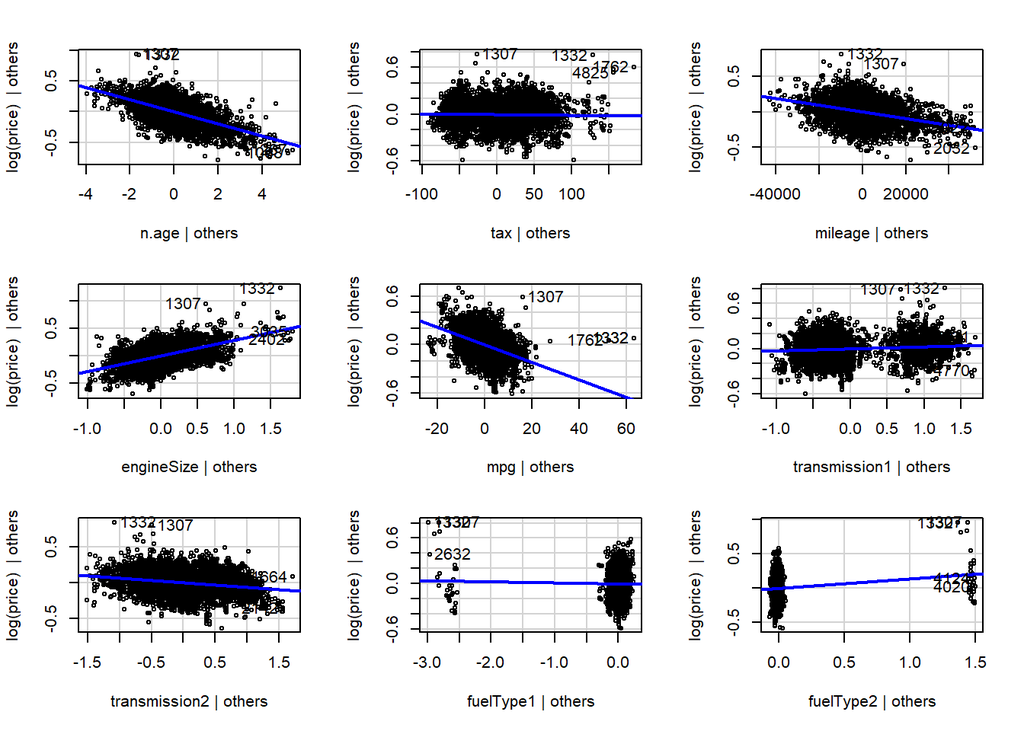

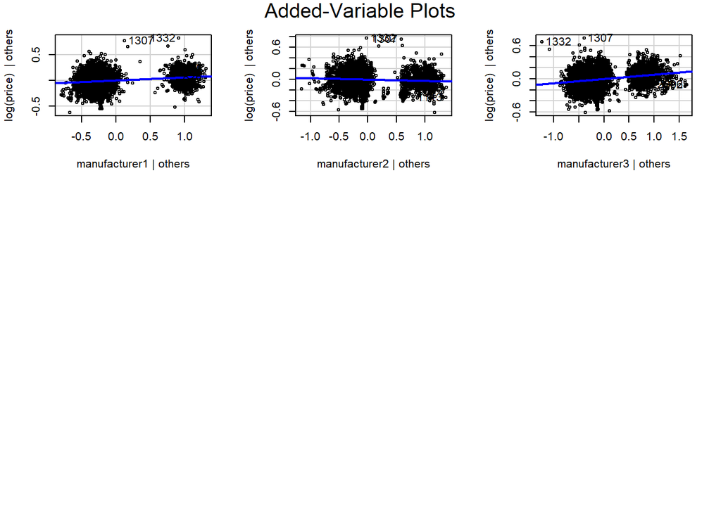

```r
avPlots(lmBest)
```

## Graphically assess the best model obtained so far.

The residuals vs Fitted plot shows that the residuals follow a good linear pattern, which meets the regression assumptions very well. The Normal Q-Q plot shows that the standard errors are mostly normally distributed with a small amount of deviating prediction at the upper end of the tail. The scale-location plot shows that homoscedasticity is satisfied as a straight line is obtained. The residuals vs leverage plot shows that our model includes some high-leverage (so highly influential in our model) points that deviate significantly (more than 4 standardized residuals away) and asymmetrically from the prediction. An influence plot further confirms this believe.

To quantify their influence, the model is reconstructed without these noteworthy points. The result is that the errors are now even more closely normally distributed around the predictions. Moreover, the new high-leverage points are more closely and symmetrically distributed around the predictions. This new model also yields a marginal R-squared improvement of about 0.3%. It can be concluded that removing the highly influential points results in more favorable diagnostic plots. This thus concludes the new best model.

```r
options(contrasts = c("contr.treatment", "contr.treatment"))
summary(lmBest)
```

```
##
## Call:
## lm(formula = log(price) ~ n.age + tax + mileage + engineSize +
##     mpg + transmission + fuelType + manufacturer, data = df)
##
## Residuals:
##      Min       1Q   Median       3Q      Max
## -0.58978 -0.09360  0.00540  0.09988  0.76947
##
## Coefficients:
##                 Estimate Std. Error t value Pr(>|t|)
## (Intercept)    1.036e+01  3.078e-02 336.468  < 2e-16 ***
## n.age         -9.847e-02  1.985e-03 -49.599  < 2e-16 ***
## tax           -9.162e-05  5.032e-05  -1.821   0.0687 .
## mileage       -4.683e-06  1.896e-07 -24.697  < 2e-16 ***
## engineSize     2.803e-01  6.564e-03  42.699  < 2e-16 ***
## mpg           -1.083e-02  3.506e-04 -30.888  < 2e-16 ***
## transmission1  2.753e-02  3.598e-03   7.651 2.39e-14 ***
## transmission2 -6.538e-02  3.860e-03 -16.940  < 2e-16 ***
## fuelType1     -1.335e-02  9.834e-03  -1.357   0.1748
## fuelType2      1.374e-01  1.880e-02   7.308 3.16e-13 ***
## manufacturer1  6.105e-02  4.120e-03  14.818  < 2e-16 ***
## manufacturer2 -2.362e-02  4.278e-03  -5.520 3.58e-08 ***
## manufacturer3  7.948e-02  4.087e-03  19.450  < 2e-16 ***
## ---
## Signif. codes:  0 '***' 0.001 '**' 0.01 '*' 0.05 '.' 0.1 ' ' 1
##
## Residual standard error: 0.1526 on 4790 degrees of freedom
## Multiple R-squared:  0.8833, Adjusted R-squared:  0.883
## F-statistic:  3021 on 12 and 4790 DF,  p-value: < 2.2e-16
```

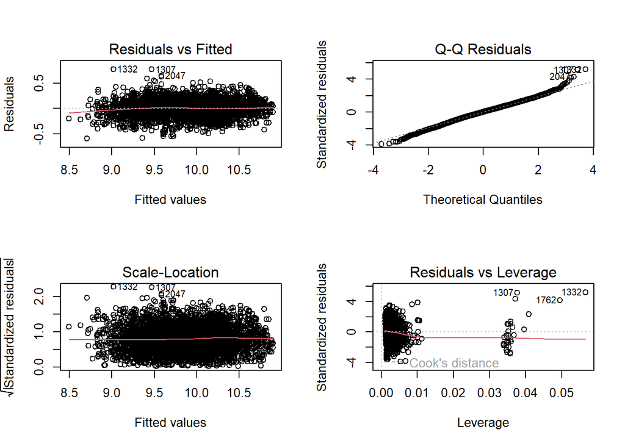

```r
par(mfrow=c(2,2))
plot(lmBest)
```

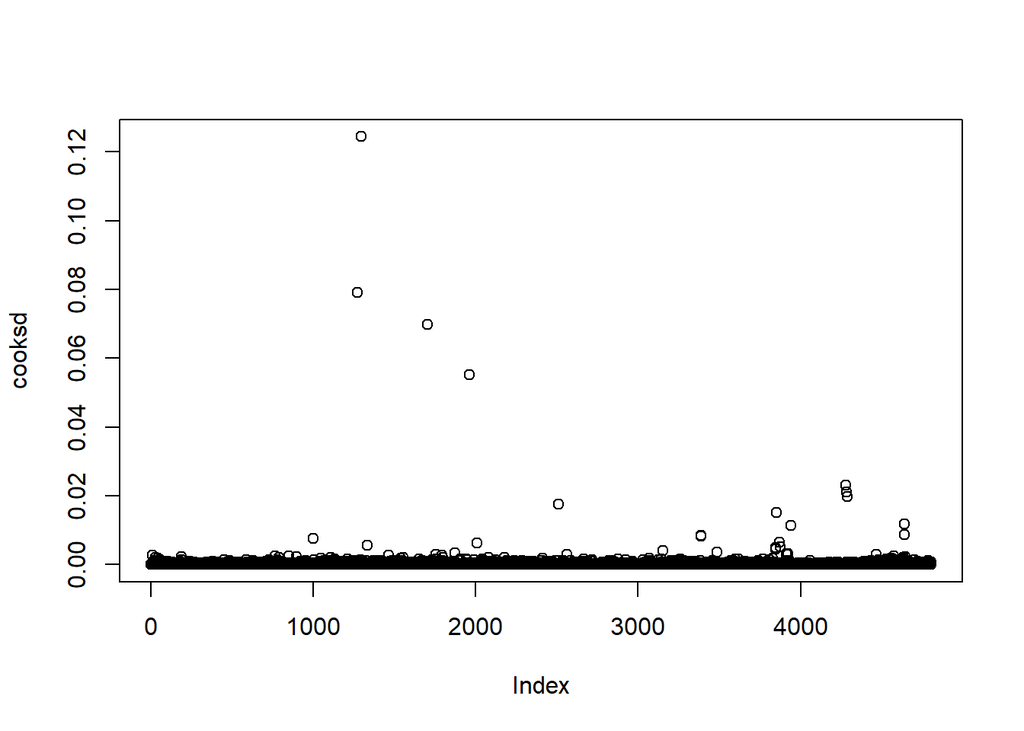

```r
par(mfrow=c(1,1))
cooksd <- cooks.distance(lmBest)
plot(cooksd)
```

```r
influencePlot(lmBest, id=list(n=3, method="noteworthy"))
```

```
##       StudRes        Hat      CookD
## 1307 5.140487 0.03767821 0.07916552
## 1332 5.205822 0.05660296 0.12439985
## 1762 4.179689 0.04949202 0.06973220
## 2047 4.320168 0.03717411 0.05522708
## 2632 2.312145 0.04092494 0.01753188
```

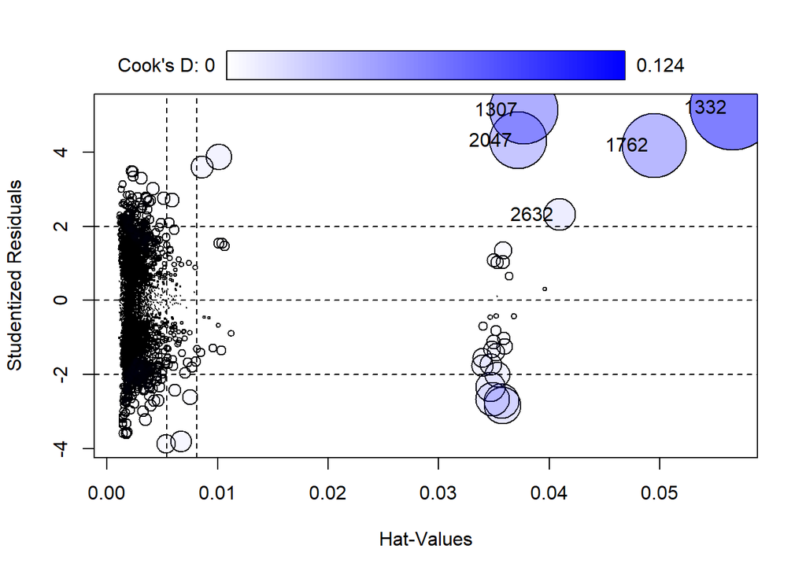

```r
high_infl = rownames(as.data.frame(influencePlot(lmBest, id=list(n=3, method="noteworthy"))))
```

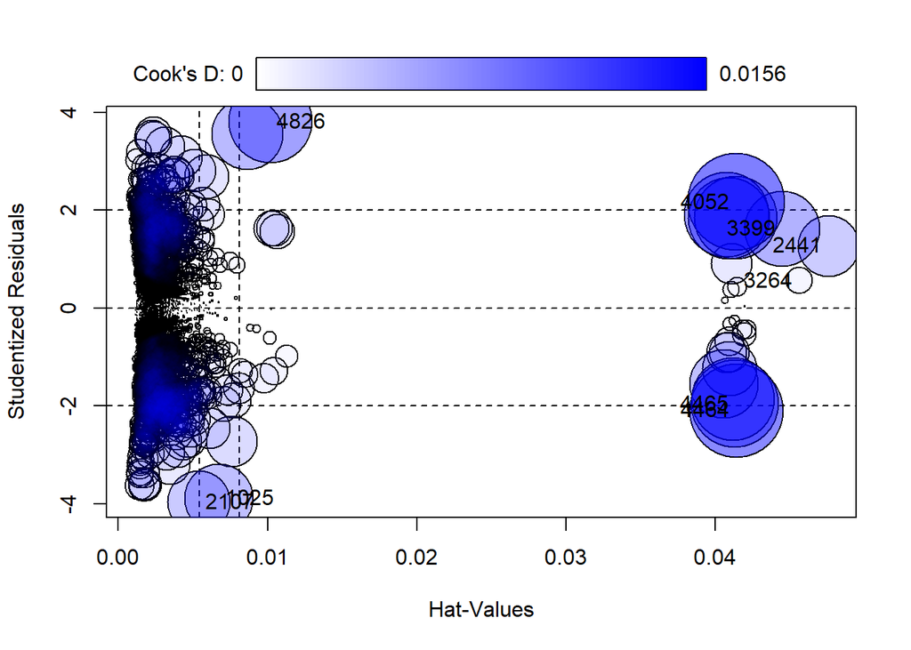

```
##         StudRes         Hat       CookD
## 1025 -3.8886239 0.006738651 0.007868251
## 2107 -3.9623479 0.005391452 0.006526544
## 2441  1.2773652 0.047571490 0.006268214
## 3264  0.5668689 0.045609399 0.001181440
## 3399  1.6225097 0.044487762 0.009425132
## 4052  2.1685055 0.041399635 0.015609921
## 4464 -2.0870569 0.041403332 0.014461726
## 4465 -1.9518934 0.041331785 0.012627858
## 4826  3.8147398 0.010193058 0.011495085
```

```r
df_no_high_infl = df[!(rownames(df) %in% high_infl),]
lmBest_no_high_infl = lm(log(price) ~ n.age+tax+mileage+engineSize+mpg+transmission+fuelType+manufacturer, data=df_no_high_infl)
influencePlot(lmBest_no_high_infl, id=list(n=3, method="noteworthy"))
```

```r
summary(lmBest)
```

```
##
## Call:
## lm(formula = log(price) ~ n.age + tax + mileage + engineSize +
##     mpg + transmission + fuelType + manufacturer, data = df)
##
## Residuals:
##      Min       1Q   Median       3Q      Max
## -0.58978 -0.09360  0.00540  0.09988  0.76947
##
## Coefficients:
##                 Estimate Std. Error t value Pr(>|t|)
## (Intercept)    1.036e+01  3.078e-02 336.468  < 2e-16 ***
## n.age         -9.847e-02  1.985e-03 -49.599  < 2e-16 ***
## tax           -9.162e-05  5.032e-05  -1.821   0.0687 .
## mileage       -4.683e-06  1.896e-07 -24.697  < 2e-16 ***
## engineSize     2.803e-01  6.564e-03  42.699  < 2e-16 ***
## mpg           -1.083e-02  3.506e-04 -30.888  < 2e-16 ***
## transmission1  2.753e-02  3.598e-03   7.651 2.39e-14 ***
## transmission2 -6.538e-02  3.860e-03 -16.940  < 2e-16 ***
## fuelType1     -1.335e-02  9.834e-03  -1.357   0.1748
## fuelType2      1.374e-01  1.880e-02   7.308 3.16e-13 ***
## manufacturer1  6.105e-02  4.120e-03  14.818  < 2e-16 ***
## manufacturer2 -2.362e-02  4.278e-03  -5.520 3.58e-08 ***
## manufacturer3  7.948e-02  4.087e-03  19.450  < 2e-16 ***
## ---
## Signif. codes:  0 '***' 0.001 '**' 0.01 '*' 0.05 '.' 0.1 ' ' 1
##
## Residual standard error: 0.1526 on 4790 degrees of freedom
## Multiple R-squared:  0.8833, Adjusted R-squared:  0.883
## F-statistic:  3021 on 12 and 4790 DF,  p-value: < 2.2e-16
```

```r
summary(lmBest_no_high_infl)
```

```
##
## Call:
## lm(formula = log(price) ~ n.age + tax + mileage + engineSize +
##     mpg + transmission + fuelType + manufacturer, data = df_no_high_infl)
##
## Residuals:
##      Min       1Q   Median       3Q      Max
## -0.59526 -0.09235  0.00555  0.10044  0.57177
##
## Coefficients:
##                         Estimate Std. Error t value Pr(>|t|)
## (Intercept)            1.049e+01  3.128e-02 335.331  < 2e-16 ***
## n.age                 -9.784e-02  1.964e-03 -49.814  < 2e-16 ***
## tax                   -1.198e-04  4.993e-05  -2.400  0.01642 *
## mileage               -4.661e-06  1.876e-07 -24.843  < 2e-16 ***
## engineSize             2.722e-01  6.544e-03  41.594  < 2e-16 ***
## mpg                   -1.159e-02  3.555e-04 -32.606  < 2e-16 ***
## transmissionManual    -9.005e-02  6.644e-03 -13.553  < 2e-16 ***
## transmissionSemi-Auto  1.195e-02  5.624e-03   2.125  0.03365 *
## fuelTypeOther          1.804e-02  3.068e-02   0.588  0.55662
## fuelTypePetrol        -1.208e-01  6.649e-03 -18.166  < 2e-16 ***
## manufacturerBMW       -8.378e-02  6.963e-03 -12.031  < 2e-16 ***
## manufacturerMercedes   2.159e-02  6.763e-03   3.192  0.00142 **
## manufacturerVW        -1.764e-01  6.260e-03 -28.178  < 2e-16 ***
## ---
## Signif. codes:  0 '***' 0.001 '**' 0.01 '*' 0.05 '.' 0.1 ' ' 1
##
## Residual standard error: 0.1509 on 4785 degrees of freedom
## Multiple R-squared:  0.8859, Adjusted R-squared:  0.8857
## F-statistic:  3097 on 12 and 4785 DF,  p-value: < 2.2e-16
```

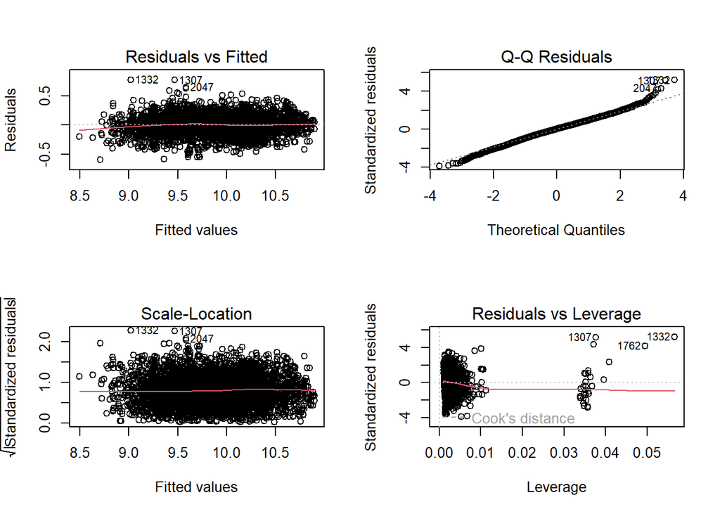

```r
par(mfrow=c(2,2))
plot(lmBest)
```

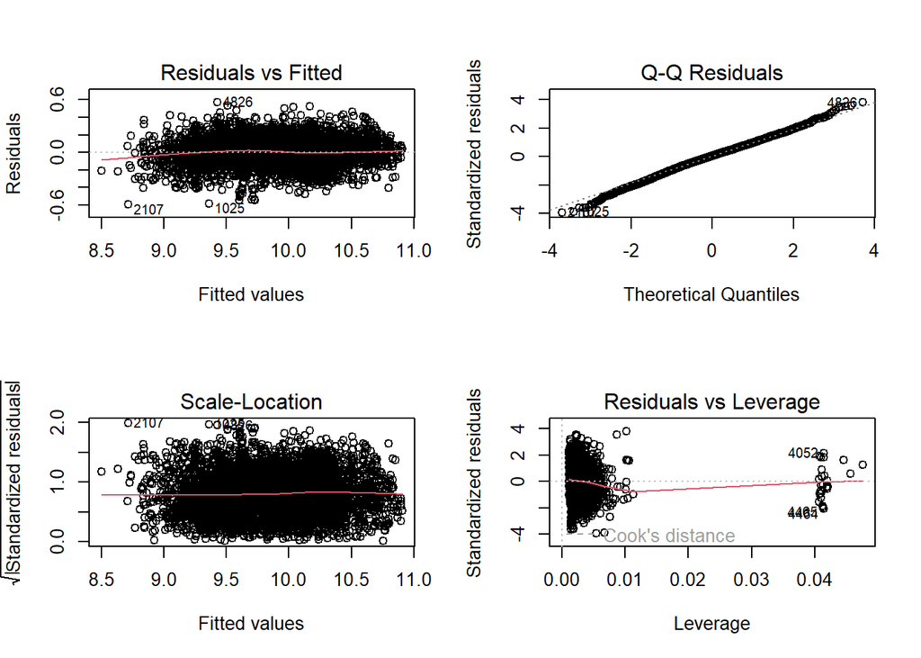

```r
plot(lmBest_no_high_infl)
```

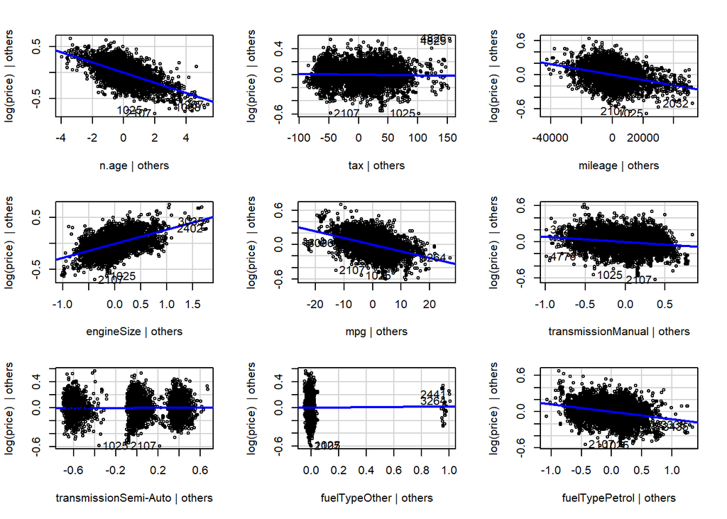

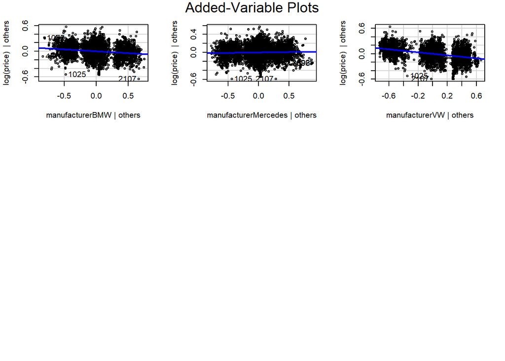

```r
lmBest = lm(log(price) ~ n.age+tax+mileage+engineSize+mpg+transmission+fuelType+manufacturer, data=df_no_high_infl)

avPlots(lmBest)
```